# How to create a statistical report with R Markdown

Anja Eggert

2021-01-22

```r
library(tidyverse)  # tibble, pipe, etc.
library(readxl)     # read in Excel data directly, in tibble format
library(factoextra) # beautiful cluster-graph with kmeans()
library(knitr)      # R Markdown and html output
library(kableExtra) # pretty html tables
```

# Chunk options

The initial line in a code chunk may include various options. For example, `echo = FALSE` indicates that the code will not be shown in the final document (though any results/output would still be displayed). You use `results = "hide"` to hide the results/output (but here the code would still be displayed). You use `include = FALSE` to have the chunk evaluated, but neither the code nor its output displayed.

etc.

# Example data set

Shotgun lipidomics was applied and 335 single metabolites were measured in two experimental groups with 14 samples in the control group and 14 samples in the treatment group. The single metabolites can be assigned to 15 lipid classes.

Lipid concentrations are given normalized to total lipids: nmol/mg lipid.

**Aim:** Detect significant differences between groups of single fatty acid metabolites (or sum of metabolites).

# Read in data

Typically, data sets are saved in Excel files. Here we read in the data using the function `read_excel()` from the **readxl-R-package**.

Then we apply following steps:

- We have a quick look at the data frame, e.g. using `str()`.
- We re-code the group labels with more clear labels.
- We apply the detection limit of the lab method to define zero values.
- Exclude the columns with sums of lipid classes, calculate here in R.
- We arrange the data frame from wide to long format.
- We export the data as a csv-file.

```r
dat <- read_excel("./data/data-lipidomics-28samples.xlsx")

dat[,1:6]
```

```
## # A tibble: 28 x 6
##    sample group `LEG in kg` `ADFI in g` `PC 14:0_16:0` `PC 14:0_18:2`
##     <dbl> <chr>       <dbl>       <dbl>          <dbl>          <dbl>
##  1      1 k            96.9       2307.          0.328          0.542
##  2      2 k           105.        2496.          0.232          0.537
##  3      3 k           110.        2817.          0.189          0.642
##  4      4 k            91.8       2183.          0.316          0.607
##  5      5 k            98         2389.          0.343          0.932
##  6      6 k            95.3       2175.          0.346          0.846
##  7      7 k            90.7       2126           0.353          0.845
##  8      8 k            99.9       2525.          0.245          0.745
##  9      9 k           110.        2450.          0.289          0.890
## 10     10 k           109.        2616.          0.289          0.642
## # ... with 18 more rows
```

```r
# here I replace k and v in group with "control" and "treatment"
dat <- dat %>%
   mutate(group = case_when(
     group == "k" ~ "control",
     group == "v" ~ "treatment"))

# here I replace all NAs and zeros with detection limit (= 0.001)
dat <- dat %>%
  replace(., . == 0 | is.na(.), 0.001)

# transpose data frame to long format
# only select columns with single lipids
dat <- dat %>%
  dplyr::select(sample, group, `LEG in kg`, `ADFI in g`, contains(":")) %>%
  gather(key = "lipid", value = "concentration",`PC 14:0_16:0`:`LPG 18:1`)

# export file as .csv (open source data format), only if it was not done yet
# 1 if-case: if (Condition) {TRUE-block}
if (!file.exists("./data/data-lipidomics-28samples.csv"))
  write.csv(dat, file = "./data/data-lipidomics-28samples.csv", row.names = FALSE)
```

# Look at the data

Here we show the data in an awesome html-style Tabel of the **kableExtra-R-package**.

To learn how to generate these tables, you can visit: [link](https://cran.r-project.org/web/packages/kableExtra/vignettes/awesome_table_in_html.html)

```r
dat %>%
  arrange(sample) %>%
  tibble::rowid_to_column("#") %>%
  kable(caption = "Data set - long format") %>%
  kable_styling(bootstrap_options = c("striped", "hover"), font_size = 10) %>%
  scroll_box(width = "600px", height = "500px")
```

Data set - long format

| # | sample | group | LEG in kg | ADFI in g | lipid | concentration |
| --- | --- | --- | --- | --- | --- | --- |
| 1 | 1 | control | 96.9 | 2307.4 | PC 14:0_16:0 | 0.3275969 |
| 2 | 1 | control | 96.9 | 2307.4 | PC 14:0_18:2 | 0.5423594 |
| 3 | 1 | control | 96.9 | 2307.4 | PC 14:0_18:0 | 0.4534255 |
| 4 | 1 | control | 96.9 | 2307.4 | PC 16:0_18:3 | 1.9658099 |
| 5 | 1 | control | 96.9 | 2307.4 | PC 16:1_18:2 | 1.6065613 |
| 6 | 1 | control | 96.9 | 2307.4 | PC 16:0_18:2 | 52.4815977 |
| 7 | 1 | control | 96.9 | 2307.4 | PC 16:0_18:1 | 19.7674541 |
| 8 | 1 | control | 96.9 | 2307.4 | PC 17:0_18:2 | 1.7885785 |
| 9 | 1 | control | 96.9 | 2307.4 | PC 17:1_18:1 | 0.7931771 |
| 10 | 1 | control | 96.9 | 2307.4 | PC 16:0_19:1 | 0.1286583 |
| 11 | 1 | control | 96.9 | 2307.4 | PC 16:0_20:5 | 0.2230125 |
| 12 | 1 | control | 96.9 | 2307.4 | PC 18:2_18:2 | 1.5544768 |
| 13 | 1 | control | 96.9 | 2307.4 | PC 16:0_20:4 | 2.0749717 |
| 14 | 1 | control | 96.9 | 2307.4 | PC 18:1_18:2 | 10.5471777 |
| 15 | 1 | control | 96.9 | 2307.4 | PC 16:0_20:3 | 1.0875556 |
| 16 | 1 | control | 96.9 | 2307.4 | PC 18:0_18:2 | 10.0026748 |
| 17 | 1 | control | 96.9 | 2307.4 | PC 18:1_18:1 | 4.2292967 |
| 18 | 1 | control | 96.9 | 2307.4 | PC 18:0_18:1 | 1.9723620 |
| 19 | 1 | control | 96.9 | 2307.4 | PC 16:0_22:6 | 0.3032378 |
| 20 | 1 | control | 96.9 | 2307.4 | PC 18:0_20:5 | 0.0678064 |
| 21 | 1 | control | 96.9 | 2307.4 | PC 18:1_20:4 | 0.3966051 |
| 22 | 1 | control | 96.9 | 2307.4 | PC 16:0_22:5 | 0.4487344 |
| 23 | 1 | control | 96.9 | 2307.4 | PC 18:0_20:4 | 0.9115821 |
| 24 | 1 | control | 96.9 | 2307.4 | PC 18:1_20:3 | 0.2865866 |
| 25 | 1 | control | 96.9 | 2307.4 | PC 18:2_20:2 | 0.2597584 |
| 26 | 1 | control | 96.9 | 2307.4 | PC 18:1_20:2 | 0.2172575 |
| 27 | 1 | control | 96.9 | 2307.4 | PC 18:2_20:1 | 0.1938222 |
| 28 | 1 | control | 96.9 | 2307.4 | PC 18:0_22:6 | 0.1177487 |
| 29 | 1 | control | 96.9 | 2307.4 | PC 18:1_22:5 | 0.1031014 |
| 30 | 1 | control | 96.9 | 2307.4 | PC 18:2_22:4 | 0.0848856 |

[output cut: 9350 more lines]

# Create summary statistics and plots

First look at the differences of the fatty acid classes between the two groups:

```r
dat %>%
  group_by(lipid,group) %>%
  summarize(mean_conc    = mean(concentration),
            sd_conc      = sd(concentration)
            )
```

```
## # A tibble: 670 x 4
## # Groups:   lipid [335]
##    lipid         group     mean_conc sd_conc
##    <chr>         <chr>         <dbl>   <dbl>
##  1 Cer 18:1/18:0 control       1.09   0.289
##  2 Cer 18:1/18:0 treatment     0.999  0.343
##  3 CL 72:8       control       0.867  0.282
##  4 CL 72:8       treatment     0.885  0.314
##  5 DAG 16:0_16:1 control       0.169  0.0620
##  6 DAG 16:0_16:1 treatment     0.143  0.0661
##  7 DAG 16:0_18:1 control       1.68   0.698
##  8 DAG 16:0_18:1 treatment     1.57   0.683
##  9 DAG 16:0_18:2 control       0.710  0.255
## 10 DAG 16:0_18:2 treatment     0.657  0.350
## # ... with 660 more rows
```

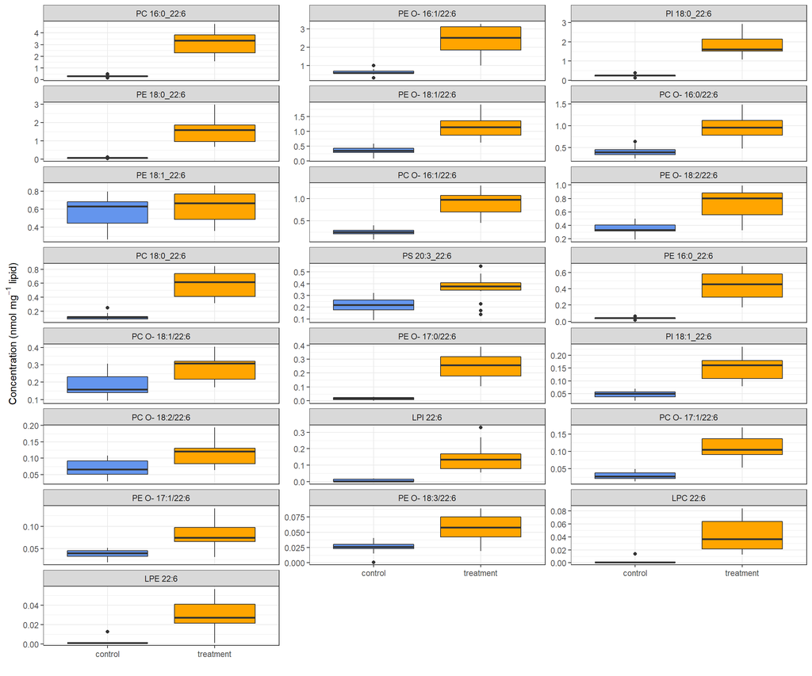

```r
dat %>%
  dplyr::filter(grepl("22:6",lipid)) %>%
  mutate(lipid = as.factor(lipid)) %>%
  mutate(lipid = reorder(lipid, -concentration)) %>%

ggplot(aes(x = group, y = concentration, fill = group))+
  geom_boxplot()+
  facet_wrap(~lipid, ncol = 3, scales = "free_y")+
  scale_fill_manual(values = c("cornflowerblue", "orange"))+
  xlab(label = "")+
  ylab(label = c(expression(paste("Concentration (nmol ", mg^-1, " lipid)"))))+
  theme_bw()+
  theme(legend.position="none")
```

```r
# You can also save the plot as png-file
# ggsave(filename = "lipids-plot.png", width = 20, height = 24, units = "cm")
```

# Multiple *t*-tests

Metabolomics data often have a log-normal distribution, i.e. the log(data) is normally distributed. We just assume this here (without any test).

We extract the *p*-values from the test results. Use `?t.test` to look at the structure of the listed results.

```r
p.val <- dat %>%
  group_by(lipid) %>%
  summarise(p.wil       = wilcox.test(concentration~group)$p.value,
            p.ttest.log = t.test(log(concentration)~group)$p.value
            ) %>%
  arrange(p.ttest.log)

# quick look at the generated p values
p.val
```

```
## # A tibble: 335 x 3
##    lipid                  p.wil p.ttest.log
##    <chr>                  <dbl>       <dbl>
##  1 PC O- 16:0/22:4 0.0000000499    9.66e-20
##  2 TAG 58:8        0.0000000499    1.13e-18
##  3 TAG 56:7        0.0000000499    1.61e-18
##  4 TAG 58:6        0.0000000499    2.22e-18
##  5 TAG 58:7        0.0000000499    3.89e-18
##  6 TAG 56:8        0.0000000499    6.69e-18
##  7 PE 18:0_22:6    0.0000000499    2.58e-17
##  8 PE O- 20:1/18:2 0.0000000499    6.43e-17
##  9 TAG 56:6        0.0000000499    6.51e-17
## 10 PC 16:0_20:5    0.0000000499    2.37e-16
## # ... with 325 more rows
```

# False Discovery Rate (FDR)

**Attention!** Modern high-throughput technologies (micro-array data, gene expressions, metabolomics data, *etc.*) generate high-dimensional data: $p>>n$.

## Some theory

How do we control the error rates in multiple comparisons? One way is to control the **familywise type 1 error rate (FWER)**, i.e. the probability of making at least one false rejection of a null hypothesis. The simplest adjustment is the Bonferroni correction, where we define a particular comparison as statistically significant only when the *p*-value is less than alpha (often 0.05) divided by the number of all comparisons:
$$p<\frac{\alpha}{m}$$
This approach is very conservative as this threshold will be very small the more comparisons are made. **False discovery rate (FDR)** controlling procedures (e.g. Benjamini-Hochberg, BH) instead control the proportion of wrongly rejected null hypotheses amongst those that are rejected. The FDR methods are more powerful than the FWER methods and are the method of choice for high-dimensional data.

## Our example

The data set obtained here using shotgun lipidomics is a typical high-dimensional data set, i.e. hundreds of lipid concentrations were measured in much less independent replicates, 335 lipid species in a control group with 14 samples and a treatment group with 14 samples. Accordingly, we made 335 comparisons, i.e. 335 individual *t*-tests were performed. Have a quick look at the distribution of the 335 *p*- values.

```r
sum(p.val$p.ttest.log<0.05)
```

```
## [1] 218
```

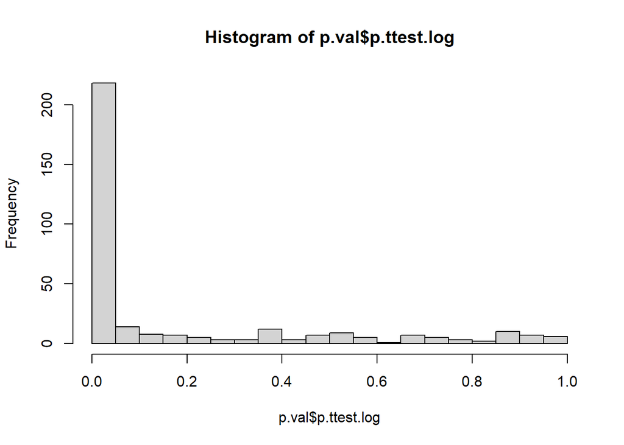

```r
hist(p.val$p.ttest.log,breaks=seq(0,1,.05))
```

*p*-values are random variables. Mathematically, one can demonstrate that under the null hypothesis (and some assumptions are met, in this case, the test statistic *t* follows standard normal distribution), *p*-values follow a uniform (0,1) distribution.

One way is to limit the FWER, e.g. by applying the Bonferroni adjustment, i.e. to decrease the individual error rate to:

$$p < \frac{\alpha}{m} = \frac{0.05}{335} = 0.000149$$

As the Bonferroni approach is very conservative, we applied a method controlling the **False Discovery Rate (FDR)** and limit the number of false positives to some value among all significant features, here to 5%.

We can use a function from base R `p.adjust()`:

```r
p.adj.BH <- p.adjust(p.val$p.ttest.log, method="fdr")

# p values not adjusted
sum(p.val$p.ttest.log < 0.05)
```

```
## [1] 218
```

```r
# pvalues with Bonferroni adjustment
sum(p.val$p.ttest.log < 0.05/335)
```

```
## [1] 143
```

```r
# pvalues with FDR adjustment
sum(p.adj.BH < 0.05)
```

```
## [1] 210
```